# Airbnb Midterm Project

Xiangliang Liu

12/8/2018

## I. Abstract

Nowadays, as the development of tourism, more and more people are willing to spend money traveling around the world. Airbnb is one of the good choices for travelers to find appropriate accommodation to meet different requirements. This report will mainly focus on predicting the price of different rooms on the Airbnb website. Specifically, the report will do analysis on Airbnb data with two method: EDA(Exploratory Data Analysis) and modeling. After reading this report, you will have a general idea how to predict the price of rooms on Airbnb website and what’s the most influential factor in predicting process.

## II. Introduction

This project will be focusing on the analysis on the relationship between price and other factors on Airbnb website. Airbnb is a privately held global company headquartered in San Francisco that operates an online marketplace and hospitality service which is accessible via its websites and mobile apps. Members can use the service to arrange or offer lodging, primarily homestays, or tourism experiences. The whole project will consist of following parts “abstract”, “introduction”, “Method”, “Result”,“Discussion”, “Acknowledgement”, “reference” and “Appendix. Firstly, I will read in the data and do some visualization to see which predictor will contributes more to the prediction of price. And then the modeling will be conducting multi-level regression using room type and neighborhood as factors to predict the price.

## III. Method

### Data source:

The data was extracted from http://tomslee.net, which can also be extracted from official Airbnb website. Specifically, the data was collected from the September 2014 to July 2017 in Boston area. There are 10 variales that will be used in this project. Specifically, they are room id, host, id room type, neighborhood, number of reviews, overall satisfaction(rating), number of accommodates, number of bedrooms and minimum stay for a visit those will be the potential factors to influence the pricing. ####overview of Airbnb data: Table 1. The head of the data:

```r
kable(head(total))
```

| room_id | host_id | room_type | borough | neighborhood | reviews | overall_satisfaction | accommodates | bedrooms | price | minstay | latitude | longitude | last_modified | survey_id | country | city | bathrooms | name | location |
| --- | --- | --- | --- | --- | --- | --- | --- | --- | --- | --- | --- | --- | --- | --- | --- | --- | --- | --- | --- |
| 5453 | 8021 | Private room | NA | Jamaica Plain | 53 | 5.0 | 2 | 1 | 171 | 1 | 42.32211 | -71.10926 | 2014-09-25 08:33:57 | NA | NA | NA | NA | NA | NA |
| 5506 | 8229 | Private room | NA | Roxbury | 30 | 4.5 | 2 | 1 | 165 | 3 | 42.32981 | -71.09560 | 2014-09-25 09:03:21 | NA | NA | NA | NA | NA | NA |
| 6695 | 8229 | Entire home/apt | NA | Roxbury | 39 | 5.0 | 4 | 1 | 222 | 3 | 42.32994 | -71.09350 | 2014-09-25 08:14:31 | NA | NA | NA | NA | NA | NA |
| 6976 | 16701 | Private room | NA | Roslindale | 26 | 5.0 | 2 | 1 | 74 | 1 | 42.29244 | -71.13577 | 2014-09-25 08:27:09 | NA | NA | NA | NA | NA | NA |
| 8789 | 26988 | Entire home/apt | NA | Downtown | 1 | 5.0 | 2 | 1 | 165 | 5 | 42.35919 | -71.06265 | 2014-09-25 08:38:21 | NA | NA | NA | NA | NA | NA |
| 8792 | 26988 | Entire home/apt | NA | Downtown | 11 | 4.5 | 3 | 1 | 228 | 5 | 42.35860 | -71.06145 | 2014-09-25 08:39:47 | NA | NA | NA | NA | NA | NA |

#### features of the dataset:

Table 2. features of the dataset:

[output not shown]

[output not shown]

room_type

neighborhood

[output not shown]

overall_satisfaction

accommodates

[output not shown]

[output not shown]

[output not shown]

[output not shown]

longitude

Min. : 4240

Length:76941

Length:76941

Min. : 0.00

Min. :0.000

Min. : 1.000

Min. : 0.00

Min. : 0.0

Min. : 1.00

Min. :42.24

Min. :-71.17

1st Qu.: 4409653

1st Qu.: 5695034

Class :character

Class :character

1st Qu.: 1.00

1st Qu.:4.000

1st Qu.: 2.000

1st Qu.: 1.00

1st Qu.: 82.0

1st Qu.: 1.00

1st Qu.:42.33

1st Qu.:-71.10

Median : 8227206

Median : 18517776

Mode :character

Mode :character

Median : 5.00

Median :4.500

Median : 2.000

Median : 1.00

Median : 140.0

Median : 2.00

Median :42.35

Median :-71.08

Mean : 8543440

Mean : 26142364

NA

NA

Mean : 18.95

Mean :3.836

Mean : 3.034

Mean : 1.27

Mean : 173.6

Mean : 2.68

Mean :42.34

Mean :-71.08

3rd Qu.:12949309

3rd Qu.: 36128699

NA

NA

3rd Qu.: 20.00

3rd Qu.:5.000

3rd Qu.: 4.000

3rd Qu.: 2.00

3rd Qu.: 218.0

3rd Qu.: 3.00

3rd Qu.:42.35

3rd Qu.:-71.06

Max. :19777573

Max. :139551362

NA

NA

Max. :470.00

Max. :5.000

Max. :16.000

Max. :10.00

Max. :10000.0

Max. :365.00

Max. :42.39

Max. :-70.99

NA

NA’s :6

NA

NA

NA

NA’s :15510

NA’s :2339

NA’s :5018

NA

NA’s :32314

NA

NA

*According to the summary we can see there are some missing values in the column of host_id, overvall_statisfaction, accommodates, bedrooms and minstay.*

*After eliminating all the miss values, we filtered the data with 0 reviews, or price = 0. the observation is meaningless if it has 0 value in number of reviews and price*

### discussion and visualization:

Table 3. Stat about the room type

```r
#categorical data:
kable(table(BostonAirbnb$room_type))
```

| Var1 | Freq |
| --- | --- |
| Entire home/apt | 14246 |
| Private room | 10706 |
| Shared room | 561 |

### EDA

Distribution of number of reviews

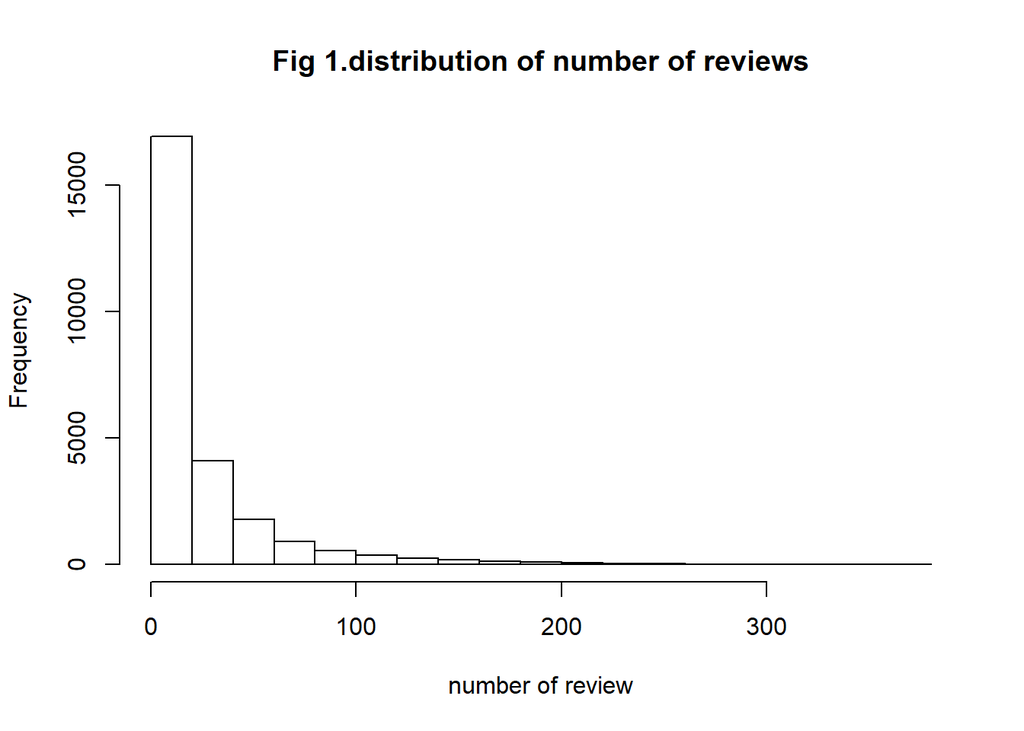

*as we can see from the distribution plot of number of reviews, most of airbnb hosts have less than 100 reviews.*

Distribution of overall satisfaction:

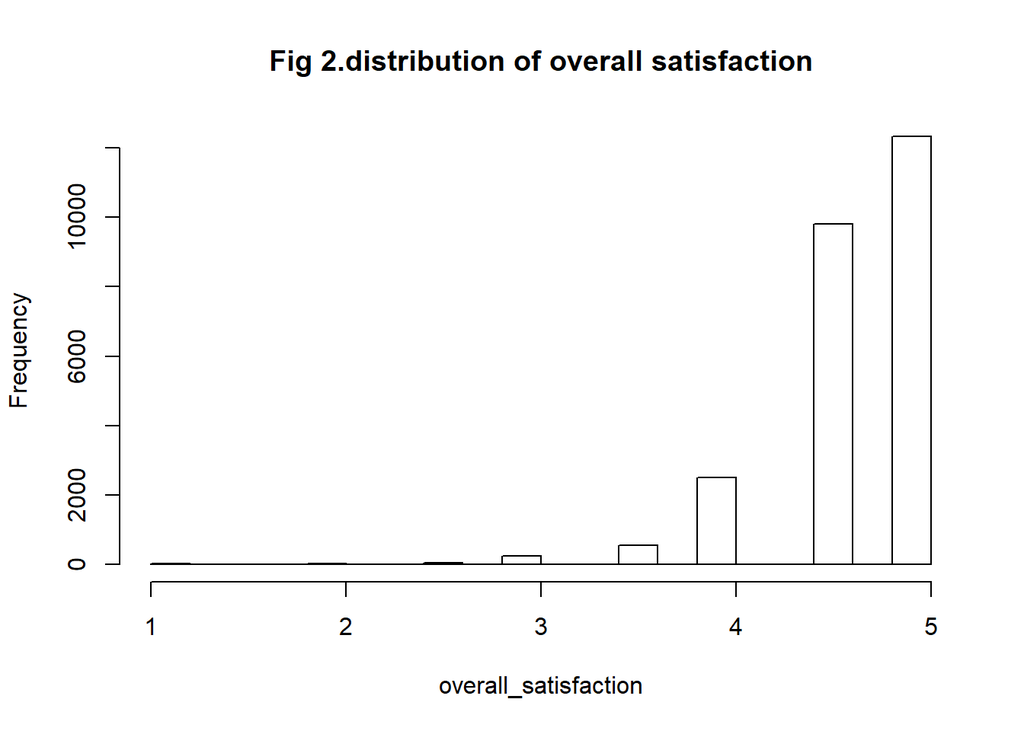

```r
hist(BostonAirbnb$overall_satisfaction, main = "Fig 2.distribution of overall satisfaction", xlab = "overall_satisfaction")
```

*in th histgram plot, most of overall rating is aroud 4.5 and 5. There are also a small portion of people rate the room 4 star. Overall, customers are satisfied with most of rooms in boston area*

*Number of room, pricing and average rating with different districts:*

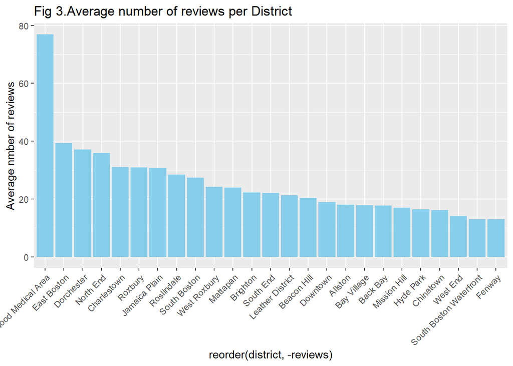

*From this plot, the district Longwood Medical area has the highest number of review (around 78), while Fenway has the lowest average number of reviews in Boston areas(around 15). So the average number of review do vary a lot by district.*

[figure not shown]

```r
  Boston_area_map <- leaflet(district) %>%
  addTiles() %>%
  addCircleMarkers(lng = district$lon,
                   lat = district$lat)
```

*As the graph showing below, we can’t tell significant diffence of rating among different neighborhoods. But we can see the average rating varys by district. Leather District has highest average rating which is close to 5. So neighborhood of the Airbnb room could be an influence predictor. We might want to include this predictor in the model to see whether rating is a significant for predicting price of rooms.*

Average rating and price with different room types.

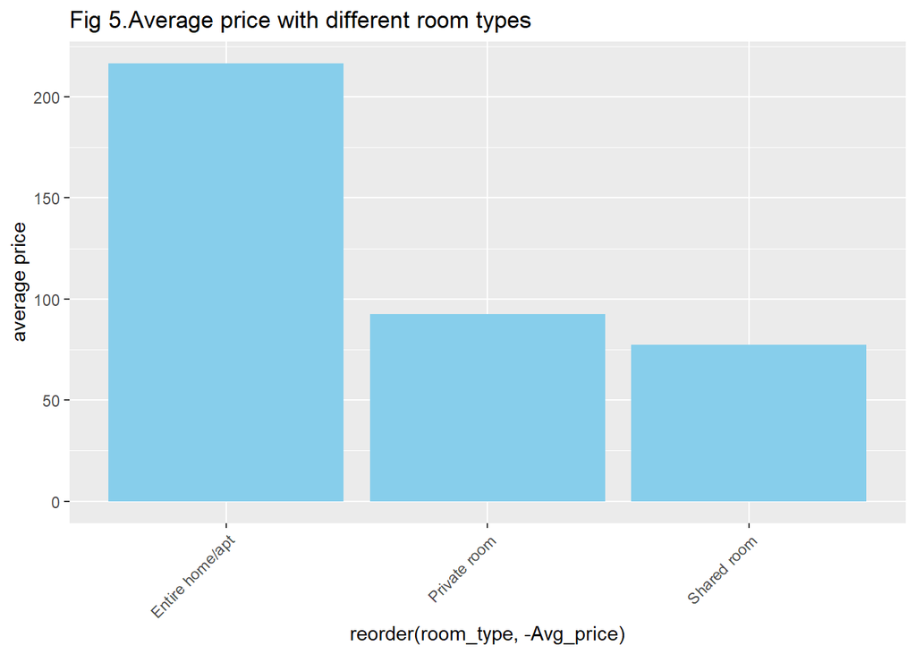

*From the plot below, we can see entire home/Apt have highest average price among all types of room. This result is reasonable because entire home/apt have more space that can serve more people, so the price is higher.*

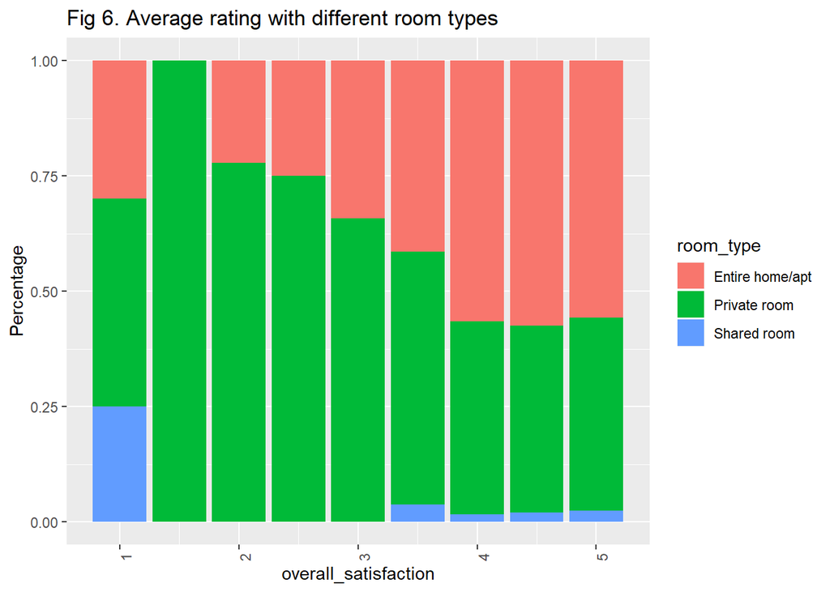

*The plot showing above indicates the proportion of room types in different score of rating. We can tell from the graph that when overall satisfaction = 1 share room has relatively larger proportion compared situations when rating equal other values. However, we can’t tell that “Entire home/apt” have higher proportion than other room type, because we found in previous EDA that the number of entire home/apt is higher than either private room or shared room.*

The accommodates and bedrooms could be two correlated terms in the model, because the number of bedroom will limit the number of customers served. So the correlation test will be conducted in next step.

```
##
##  Pearson's product-moment correlation
##
## data:  BostonAirbnb$accommodates and BostonAirbnb$bedrooms
## t = 150.06, df = 25511, p-value < 2.2e-16
## alternative hypothesis: true correlation is not equal to 0
## 95 percent confidence interval:
##  0.6781395 0.6911761
## sample estimates:
##       cor
## 0.6847126
```

*the p-value of this test is 2.2e-16. Reject the null hypothesis. So correlation between the those two variables is significant. we might want to add the correlation term into the model to test whether this influence term is significant*

Before going further, we want to verify the distribution of the response variable–price, to test the assumption that it is normal distributed.

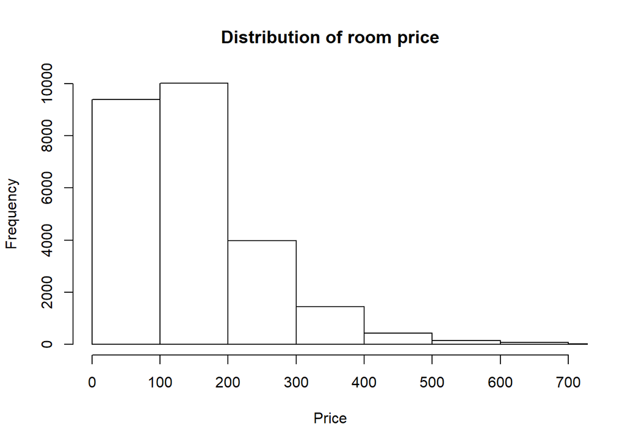

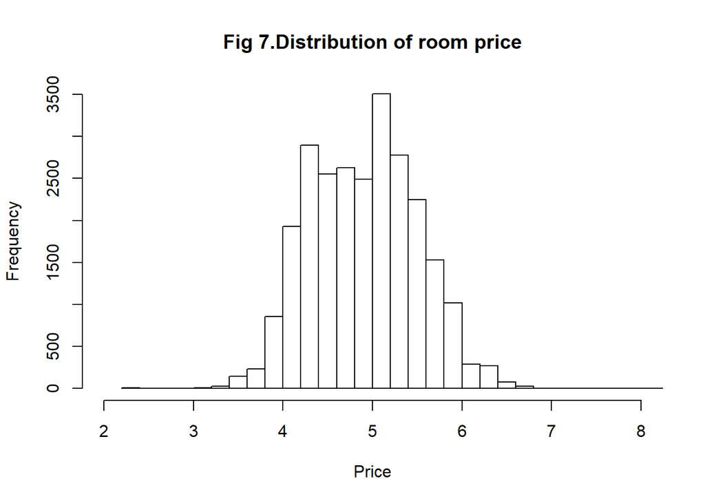

*The first histogram distribution plot obviously does not follow normal distribution. After doing the log transformation, we got the second histogram plot. Now it looks like it follows normal distribution.*

### Modelling:

#### Model1: Simple linear regression:

$$log(price) = \alpha + \beta_1 x_{room_type} +\beta_2 x_{reviews} + \beta_3x_{reviews} +\beta_4x_{accommodates*bedrooms} + \beta_5 x_{accommodates}+\beta_6 x_{bedrooms} +\beta_7 x_{minstay}$$

```
##
## Call:
## lm(formula = logprice ~ room_type + reviews + overall_satisfaction +
##     accommodates * bedrooms + minstay - 1, data = df)
##
## Residuals:
##     Min      1Q  Median      3Q     Max
## -2.7851 -0.2499 -0.0045  0.2530  4.0263
##
## Coefficients:
##                            Estimate Std. Error t value Pr(>|t|)
## room_typeEntire home/apt  4.444e+00  2.842e-02 156.360  < 2e-16 ***
## room_typePrivate room     3.759e+00  2.755e-02 136.443  < 2e-16 ***
## room_typeShared room      3.566e+00  3.188e-02 111.857  < 2e-16 ***
## reviews                  -1.151e-03  6.851e-05 -16.793  < 2e-16 ***
## overall_satisfaction      8.935e-02  5.585e-03  15.998  < 2e-16 ***
## accommodates              7.205e-02  3.626e-03  19.871  < 2e-16 ***
## bedrooms                  1.829e-01  7.785e-03  23.494  < 2e-16 ***
## minstay                  -1.986e-03  4.103e-04  -4.840 1.30e-06 ***
## accommodates:bedrooms    -9.405e-03  1.408e-03  -6.681 2.42e-11 ***
## ---
## Signif. codes:  0 '***' 0.001 '**' 0.01 '*' 0.05 '.' 0.1 ' ' 1
##
## Residual standard error: 0.3904 on 25504 degrees of freedom
## Multiple R-squared:  0.9937, Adjusted R-squared:  0.9937
## F-statistic: 4.505e+05 on 9 and 25504 DF,  p-value: < 2.2e-16
```

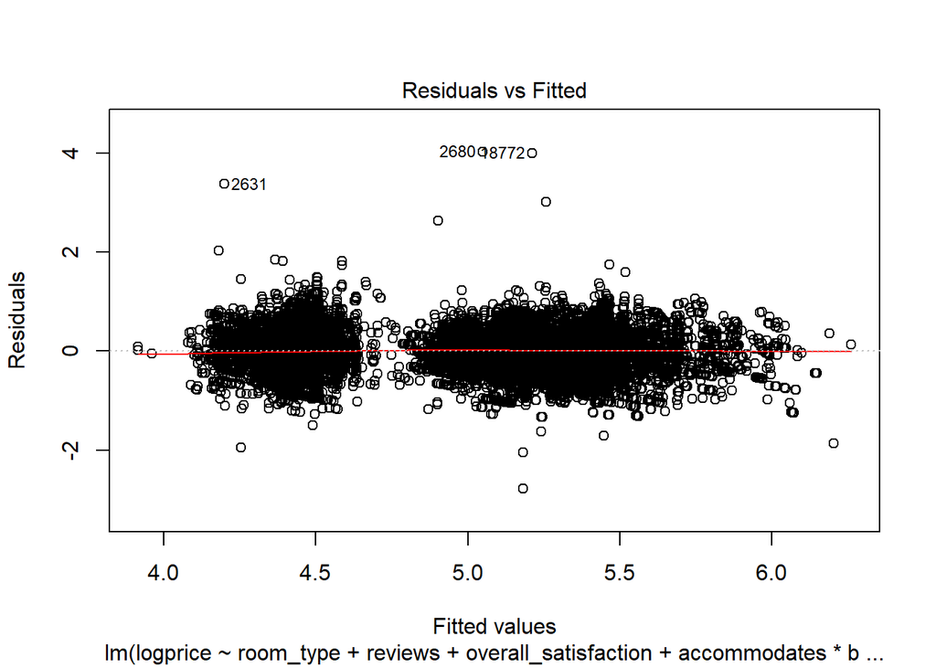

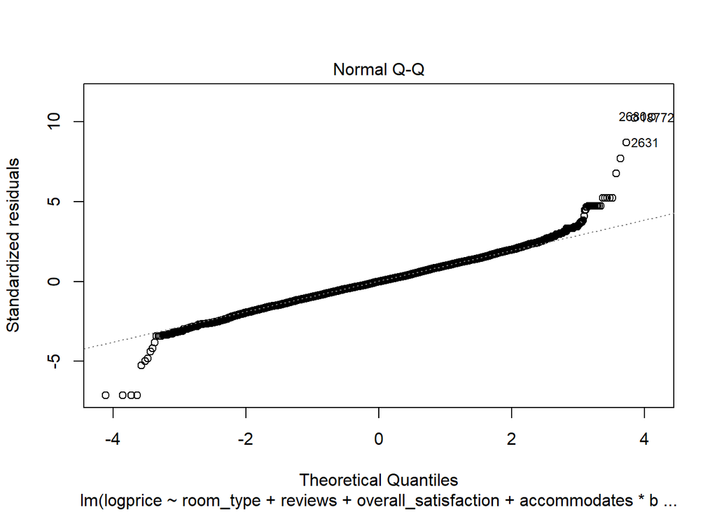

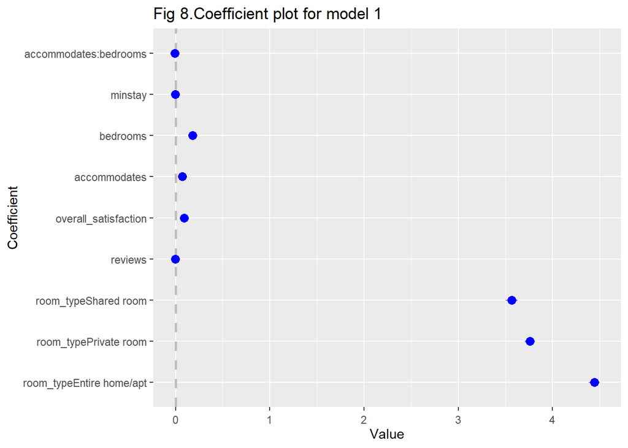

*Though all the coefficients are significant in previous summary checking. The coefficient plot tell us the predictor: “reviews”, “minstays” and correlation accommodates:bedrooms coefficient exactly fall on the zero point. We may want to eliminate those predictors in the multilevel models. Now let’s expand simple linear model to multilevel linear model. ####Model2: Multilevel linear model with random intercept:

$$log(price) = \alpha_{i} + \beta_1 x_{room_type} +\beta_2 x_{overall satisfaction} +\beta_3x_{accommodates*bedrooms} + \beta_4 x_{accommodates}+\beta_6 x_{bedrooms}$$

```
## lmer(formula = logprice ~ room_type + overall_satisfaction +
##     accommodates + bedrooms + (1 | neighborhood) - 1, data = df)
##                          coef.est coef.se
## room_typeEntire home/apt 4.32     0.06
## room_typePrivate room    3.87     0.06
## room_typeShared room     3.55     0.06
## overall_satisfaction     0.08     0.00
## accommodates             0.06     0.00
## bedrooms                 0.20     0.00
##
## Error terms:
##  Groups       Name        Std.Dev.
##  neighborhood (Intercept) 0.28
##  Residual                 0.33
## ---
## number of obs: 25513, groups: neighborhood, 25
## AIC = 16535.5, DIC = 16423
## deviance = 16471.3
```

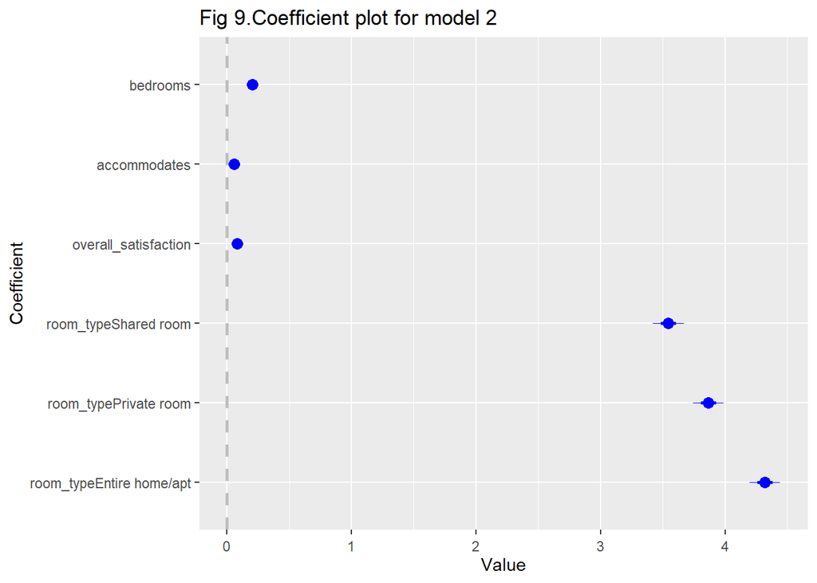

*This model gets rid of a few non-significant terms we discussed previously such as interaction between accommodate and bedrooms. In the coefficient plot, all the predictors are significant. And the facotor of room type, room type plays the most important part in the model. Besides, the room types the number of bedrooms is the second influential term in this model*

#### Model3 : Multilevel linear model with random slope:

$$log(price) = \alpha + \beta_1 x_{room_type} +\beta_2 x_{overallsatisfaction}_{i} + \beta_3 x_{accommodates}+\beta_4 x_{bedrooms}$$

```
## lmer(formula = logprice ~ room_type + overall_satisfaction +
##     accommodates + bedrooms + (0 + overall_satisfaction | neighborhood) -
##     1, data = df)
##                          coef.est coef.se
## room_typeEntire home/apt 4.30     0.02
## room_typePrivate room    3.84     0.02
## room_typeShared room     3.52     0.03
## overall_satisfaction     0.09     0.01
## accommodates             0.06     0.00
## bedrooms                 0.20     0.00
##
## Error terms:
##  Groups       Name                 Std.Dev.
##  neighborhood overall_satisfaction 0.06
##  Residual                          0.33
## ---
## number of obs: 25513, groups: neighborhood, 25
## AIC = 16660.8, DIC = 16548.2
## deviance = 16596.5
```

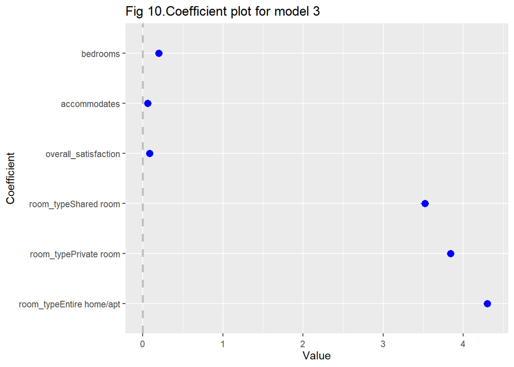

*This is a multilevel linear model with random slope. As we can see from the coefficient plot, all the predictors are significant.*

#### model4 : Multilevel linear model with random slope and random intercept.

$$log(price) = \alpha_{i} + \beta_1 x_{room_type} +\beta_{2[i]} x_{overall satisfaction} + \beta_3 x_{accommodates}+\beta_4 x_{bedrooms}$$

```
## lmer(formula = logprice ~ room_type + overall_satisfaction +
##     bedrooms + accommodates + (1 + overall_satisfaction | neighborhood) -
##     1, data = df)
##                          coef.est coef.se
## room_typeEntire home/apt 4.34     0.11
## room_typePrivate room    3.88     0.11
## room_typeShared room     3.56     0.11
## overall_satisfaction     0.08     0.02
## bedrooms                 0.20     0.00
## accommodates             0.06     0.00
##
## Error terms:
##  Groups       Name                 Std.Dev. Corr
##  neighborhood (Intercept)          0.51
##               overall_satisfaction 0.09     -0.83
##  Residual                          0.33
## ---
## number of obs: 25513, groups: neighborhood, 25
## AIC = 16313, DIC = 16202
## deviance = 16247.5
```

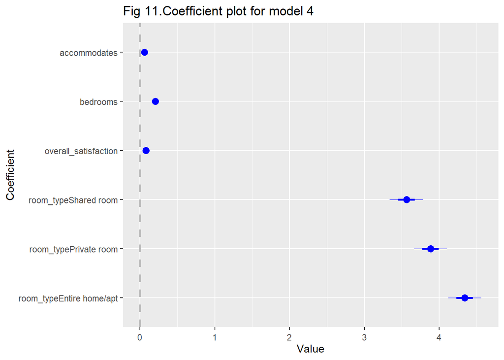

*This is the model is based on model2 and model3 with random slope as well random intercept. Again from the coefficient plot, all the predictors are significant.*

## Result:

### Model Choice and Interpretation:

Since we have 3 multilevel models with similar structures, we want to run ANOVA test to test whether there’s any difference among the models and which model has best goodness of fit.

```
## Data: df
## Models:
## model2: logprice ~ room_type + overall_satisfaction + accommodates +
## model2:     bedrooms + (1 | neighborhood) - 1
## model3: logprice ~ room_type + overall_satisfaction + accommodates +
## model3:     bedrooms + (0 + overall_satisfaction | neighborhood) - 1
## model4: logprice ~ room_type + overall_satisfaction + bedrooms + accommodates +
## model4:     (1 + overall_satisfaction | neighborhood) - 1
##        Df   AIC   BIC  logLik deviance Chisq Chi Df Pr(>Chisq)
## model2  8 16536 16601 -8259.8    16520
## model3  8 16661 16726 -8322.4    16645   0.0      0          1
## model4 10 16313 16395 -8146.5    16293 351.8      2     <2e-16 ***
## ---
## Signif. codes:  0 '***' 0.001 '**' 0.01 '*' 0.05 '.' 0.1 ' ' 1
```

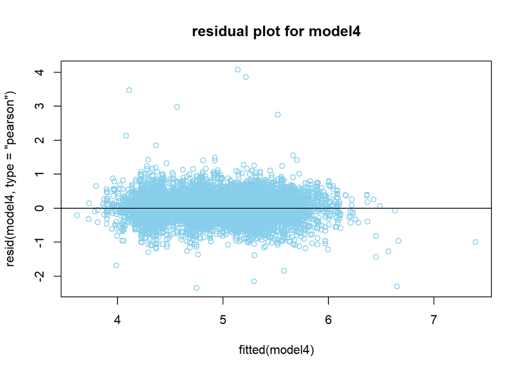

```
## [1] 0.7954577
```

From the analysis above we found the best model among is the follow one:
$$log(price) = \alpha_{i} + \beta_1 x_{room_type} +\beta_{2[i]} x_{overall satisfaction} + \beta_3 x_{accommodates}+\beta_4 x_{bedrooms}$$
*The strategy of this model is predicting models by different levels of neighborhood. The model in each level will contain a unique intercept and a unique slope for the predictor overall satisfaction. This structure of will lead this model to minimize the deviance comparing to the other two multilevel linear model. From the coefficient plot, the most influential term is the factor of room type. The second influential term is the district of neighborhood. Also, more bedrooms and higher overall satisfaction will lead to a higher price.

## Discussion:

### Implication

The result of modeling is what we expected at initial. The factor of room type will determine the number of customers served. For example, entire home/apt tends to serve more people at one time. So the price of entire home/apt should be higher than the other two room type. Also, the second term neighborhood is obvious to be significant. This is because different districts have different environment condition. For example, Bay village is close to downtown area and there are many sight-seeing spots for tourists. We can conclude that our findings are reasonable.

### Limitation

First, the dataset is limited in the Boston area. So, it is not enough to predict the Airbnb room price in other area. Second, there are only 4 predictors in the multilevel model. Those predictors are the most significant variables we found in the dataset. However, there are many other factors that may influence the price of rooms. For example, the crime rate in the neighborhood or the transportation condition. Those could be potential influence terms.

### Future direction

In the future, I will try to include more predictors with a bigger dataset. This will help predict the price more precisely and find more factors that influence the room price.

## Acknowledgement

Special thanks to Professor Yajima’s suggestion on model fitting and solutions to the problem “do not converge” when I was fitting a multilevel model. And thank the data provider on tomslee’s website.

## Reference

http://tomslee.net https://en.wikipedia.org/wiki/Airbnb https://www.airbnb.com/

## Appendix

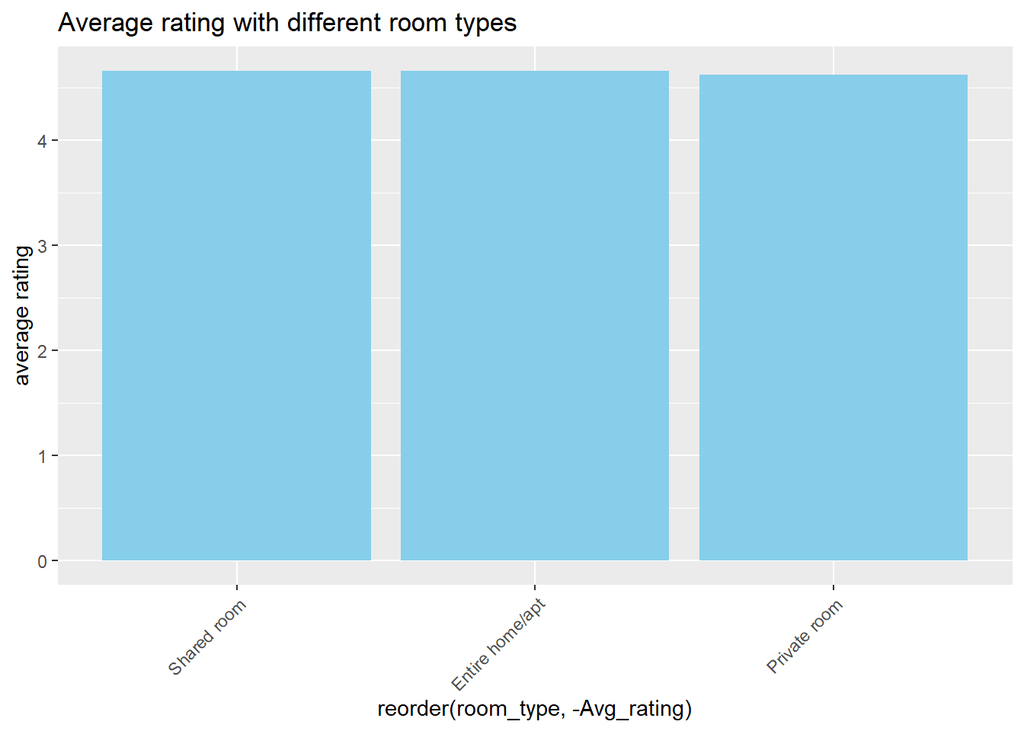

* The graph above shows the average rating with different room types. However we can’t tell any difference among those three types. This is because the overall rating in Boston area are all very hight(above 4.5).*

[figure not shown]

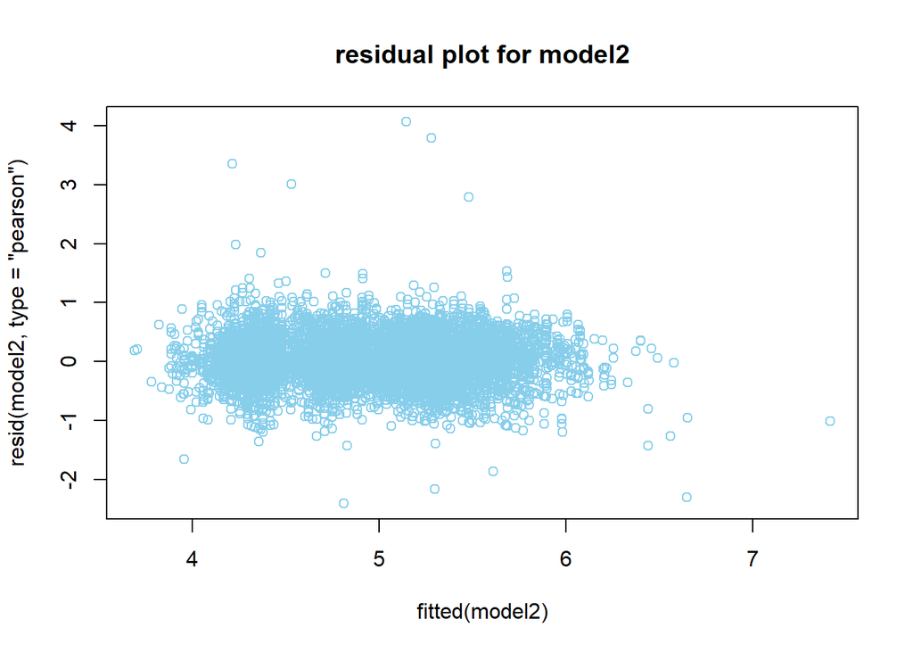

[figure not shown]